# Portfolio 2.2, Methods 3, 2021, autumn semester

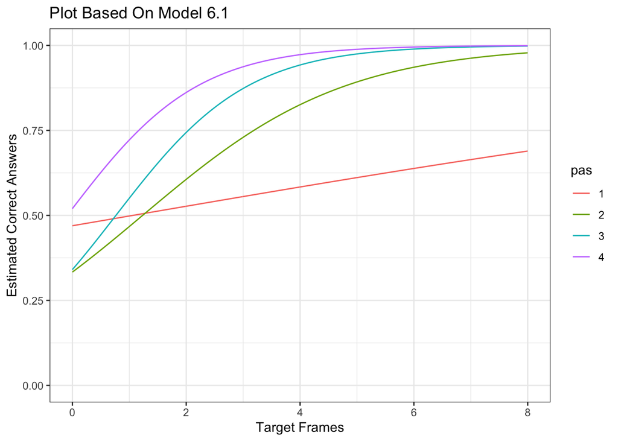

```r
#plot
plot6.1 <- model6_pivot %>%
  ggplot(aes(x = x, y = yhat_model6, colour = pas)) +
  xlim(c(0,8))+
  ylim(c(0,1))+
  geom_line(aes(x = x, y = yhat_model6))+
  labs(title = "Plot Based On Model 6.1",
       x = "Target Frames",
       y = "Estimated Correct Answers")+
  theme_bw()

plot6.1
```

$~$

*This can now be compared to the sigmoid function plot over pas ratings.*

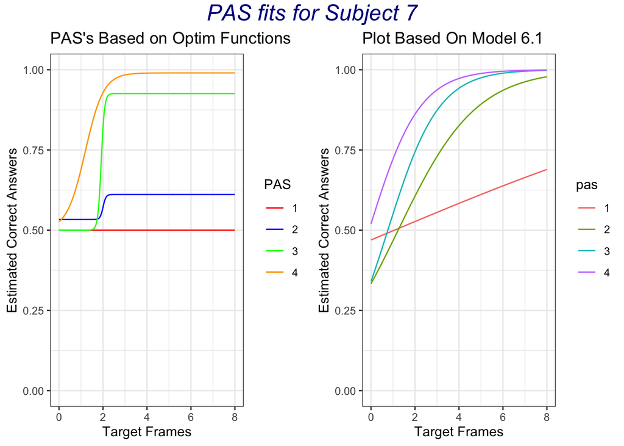

```r
cool_com <- ggarrange(plot_optim, plot6.1)
annotate_figure(cool_com, top = text_grob("PAS fits for Subject 7", color = "darkblue", face = "italic", size = 18))
```

$~$ iv. Comment on the differences between the fits - mention some advantages and disadvantages of each way  
*The plot appears to have quite the same tendencies, at first glance. However, by a closer look especially pas 2 differs a lot in its relation to the other lines in the two plots. In the optim function the correctness is quite low, whereas it is almost as good as in pas 3 in the model 6.1 plot.*

*By looking at the Optim plot, we see how the optim function has fixed the problem of having less correct answers then if due to chance, which I’d say is a big advantage! This stems from us setting the accepted minimum at a=0.5. This however can’t be done when the correctness of answers are estimated on the general mixed model m6.1, thus we see the slopes being below 0.5 in the model 6.1 plot.*

2. Finally, estimate the parameters for all subjects and each of their four PAS ratings. Then plot the estimated function at the group-level by taking the mean for each of the four parameters, *a*, *b*, *c* and *d* across subjects. A function should be estimated for each PAS-rating (it should look somewhat similar to Fig. 3 from the article: https://doi.org/10.1016/j.concog.2019.03.007)

```r
#making a loop that creates pas ratings estimated by the optim function per subject
cool_loop_function <- function(){
  data_frame_parameters <- data.frame(subject = NA, pas = NA , a = NA, b = NA, c = NA, d = NA)


  for (i in 1:4){
    df_temp1 <- data_exp %>%
      filter(pas == i) %>%
      mutate(subject = as.numeric(subject))

    for (ii in 1:length(unique(data_exp$subject))){
      data_temp <- df_temp1 %>%
        filter(subject == ii) %>%
        dplyr::select(target.frames, correct, pas) %>%
        rename(x = target.frames, y = correct)

      op_temp = optim(par = c(0.5,0.5,1,1), fn = RSS, data = data_temp, method = "L-BFGS-B", lower = c(0.5,0.5,-Inf,-Inf),
      upper = c(1,1,Inf,Inf))
      data_frame_parameters <- rbind(data_frame_parameters , c(ii,i,op_temp$par))

    }
  }
  return(data_frame_parameters)
}

df_loop_pasratings <- cool_loop_function() %>%
  na.omit() #removing na's



df_loop_pasratings
```

|  | subject | pas | a | b | c | d |
| --- | --- | --- | --- | --- | --- | --- |
| 2 | 1 | 1 | 0.5000000 | 0.5000000 | 1.0000000 | 1.0000000000 |
| 3 | 2 | 1 | 0.6072665 | 0.5000000 | 0.9206736 | 0.7154031594 |
| 4 | 3 | 1 | 0.6248181 | 0.5374096 | 0.8602455 | 0.4300550152 |
| 5 | 4 | 1 | 0.7593121 | 0.5000000 | 0.9151872 | 0.0932777361 |
| 6 | 5 | 1 | 0.5000000 | 0.5000000 | 1.0000000 | 1.0000000000 |
| 7 | 6 | 1 | 0.6143188 | 0.5000000 | 1.0058600 | 0.9558662745 |
| 8 | 7 | 1 | 0.5000000 | 0.5000000 | 1.0000000 | 1.0000000000 |
| 9 | 8 | 1 | 0.6165075 | 0.5000000 | 0.9436198 | 0.8557934710 |
| 10 | 9 | 1 | 0.5000000 | 0.5391376 | 1.7117410 | 0.0203760864 |
| 11 | 10 | 1 | 0.5000000 | 0.5000000 | 1.0000000 | 1.0000000000 |

[output cut: 106 more lines]

$~$ *this now gives us a dataframe containing the parameters for each subject in each pas, which we then can take the mean of:*

```r
#taking the average of all subjects ratings per pas:
mean_rating <- df_loop_pasratings %>%
  group_by(pas) %>%
  summarise(a = mean(a), b = mean(b), c = mean(c), d = mean(d))
mean_rating
```

| pas | a | b | c | d |
| --- | --- | --- | --- | --- |
| 1 | 0.5796431 | 0.5514403 | 1.638810 | 0.4571415 |
| 2 | 0.5274088 | 0.8775388 | 2.832406 | 0.1749703 |
| 3 | 0.5768916 | 0.9556266 | 2.281409 | 0.2259202 |
| 4 | 0.7198609 | 0.9658502 | 2.190136 | 0.5012006 |

$~$ *Having the mean of each parameter in each class we can now estimate the y values for all subjects, which is originally estimated by the optim.*

```r
#making y values per pass:
y_for_pas <- function() {
  x <- seq(1, 8, 0.1)
  y_df = data.frame(x)

  for (i in 1:4){
  df_temp <- mean_rating %>%
      filter(pas == i)

   y_df[,i+1] <- y_hat_func(df_temp$a, df_temp$b, df_temp$c, df_temp$d, x)

  }
y_df <- y_df %>%
  rename("1" = V2, "2" = V3, "3" = V4, "4" = V5)

return(y_df)

}

df_est_pas <- y_for_pas()
df_est_pas
```

| x | 1 | 2 | 3 | 4 |
| --- | --- | --- | --- | --- |
| 1.0 | 0.5740525 | 0.5274187 | 0.5781904 | 0.7408026 |
| 1.1 | 0.5730071 | 0.5274264 | 0.5789097 | 0.7449551 |
| 1.2 | 0.5718338 | 0.5274399 | 0.5800241 | 0.7498215 |
| 1.3 | 0.5705406 | 0.5274638 | 0.5817460 | 0.7554794 |
| 1.4 | 0.5691434 | 0.5275062 | 0.5843954 | 0.7619973 |
| 1.5 | 0.5676663 | 0.5275813 | 0.5884460 | 0.7694269 |
| 1.6 | 0.5661399 | 0.5277142 | 0.5945791 | 0.7777943 |
| 1.7 | 0.5645993 | 0.5279493 | 0.6037297 | 0.7870907 |
| 1.8 | 0.5630810 | 0.5283649 | 0.6170872 | 0.7972649 |
| 1.9 | 0.5616194 | 0.5290985 | 0.6359767 | 0.8082177 |

[output cut: 61 more lines]

$~$ *Plotting the estimated function at the group-level by taking the mean for each of the four parameters, *a*, *b*, *c* and *d* across subjects:*

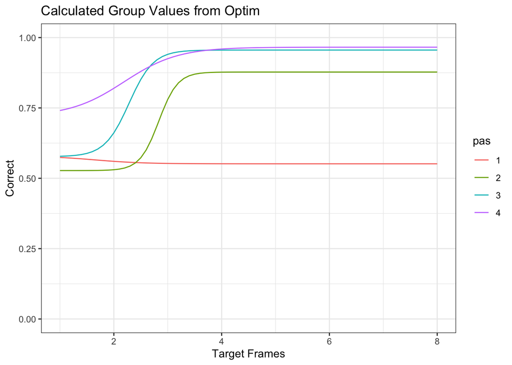

```r
df_final <- df_est_pas %>%
  pivot_longer(cols = c("1", "2","3", "4") , names_to = "pas", values_to = "y_hat_merged")

plot_final <- df_final %>%
  ggplot(aes(x, y_hat_merged, color = pas))+
  geom_line() +
  ylim(0,1)+
  labs(title = "Calculated Group Values from Optim",
       x = "Target Frames",
       y = "Correct") +
  theme_bw()

plot_final
```

$~$ i. compare with the figure you made in 5.3.ii and comment on the differences between the fits - mention some advantages and disadvantages of both.

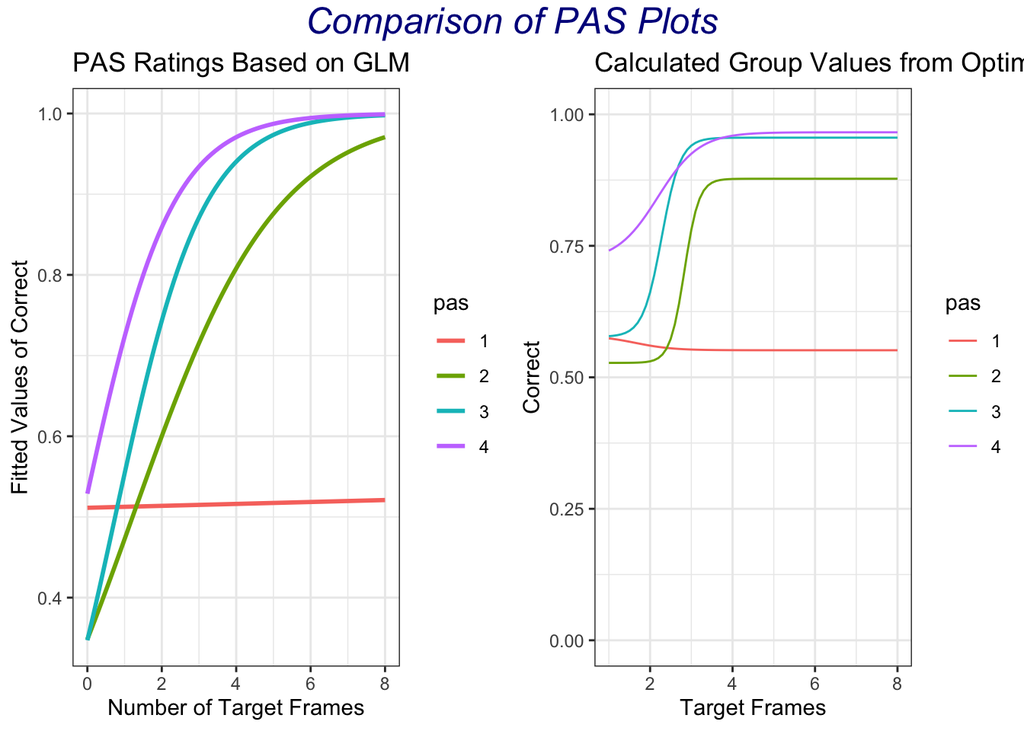

```r
last_com <- ggarrange(plot_5.3 , plot_final)
annotate_figure(last_com, top = text_grob("Comparison of PAS Plots", color = "darkblue", face = "italic", size = 18))
```

$~$ *Just by eyeballing the plots, the lines for each pas is quite similar in relationship to one another.* *Looking at the optim group plot at the right the line for pas 1 is weird looking, since it between target frame 1-3 it declines, since a is higher than b (as found in df_loop_pasratings). However in this plot (group optim) the lines are not at any point below 0.5 on the y axes, which is an advantages the GLM plot does not have - this means that the estimated accuracy of correct answers never gets worse than by due to chance.* *Moreover, The GLM plot doesn’t seem to act as an entire sigmoid function either, which I intuitively would say it should, to reflect the data properly - an ability the group optim plot possesses.*